# Exploring growth rates IWYP

A Bowerman, D Ganguly

21/05/2019

## Aim

Calculate growth rates from NDVI data.

## Method

Utilise measures of Normalized Vegetation Index (NDVI, Greenseeker) to estimate growth rates using a nonlinear modelling approach [Paine et al 2012](https://besjournals.onlinelibrary.wiley.com/doi/full/10.1111/j.2041-210X.2011.00155.x).

Also see [Fitting von Bertalanffy Growth Function](http://rpubs.com/lacs/1123) and [fishR](http://derekogle.com/fishR/examples/oldFishRVignettes/VonBertalanffy.pdf).

## Results

As an initial exploratory exercise, we can produce a heatmap to look at individual growth behaviours.

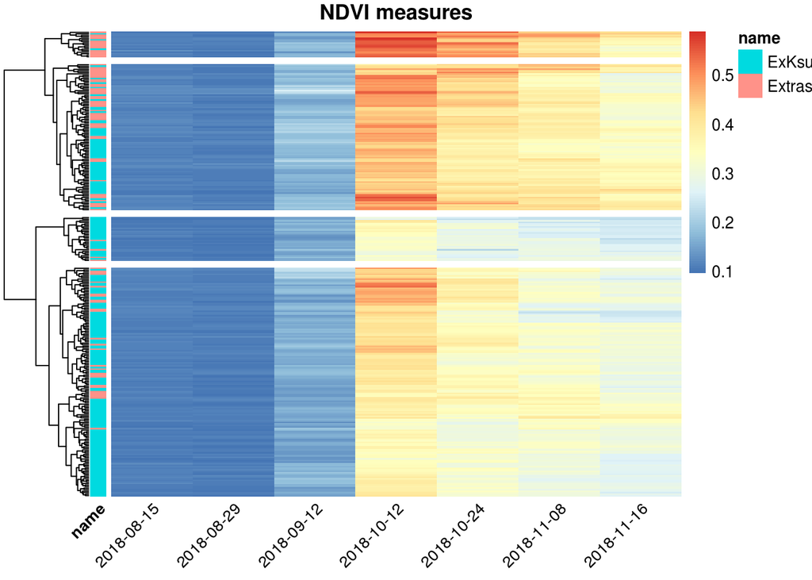

```r
library(pheatmap)

## make numeric matrix and heatmap
my_mat <- select(dat, germinatebase_id, date, value) %>% group_by(germinatebase_id,
    date) %>% summarise(avg = mean(value)) %>% spread(date, avg)

my_mat <- as.data.frame(my_mat)
rownames(my_mat) <- my_mat$germinatebase_id
my_mat <- as.matrix(my_mat[2:ncol(my_mat)])

# define accession annotations
my_grps <- select(accs, foreign_id, name)
my_grps <- subset(my_grps, foreign_id %in% rownames(my_mat))
rownames(my_grps) <- my_grps$foreign_id
my_grps$foreign_id <- NULL

pheatmap(mat = my_mat, show_rownames = F, main = "NDVI measures", annotation_row = my_grps,
    cutree_rows = 4, cluster_cols = FALSE, angle_col = 45)
```

We can arbitrarily group the data into 4 temporal patterns (cutree algorithm). Interestingly, the data doesn’t completely separate by panel.

We can also plot raw NDVI values with a generic loess polynomial fit.

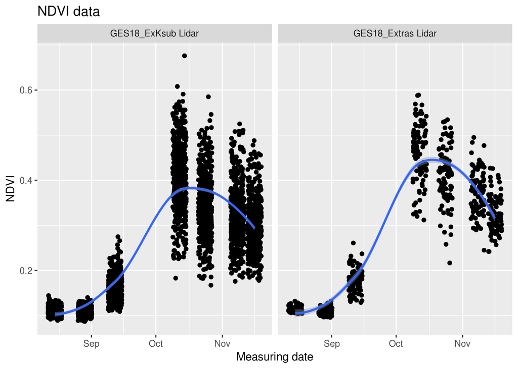

```r
library(ggplot2)
library(patchwork)

### plot jitter
ggplot(dat, aes(x = date, y = value)) + geom_jitter() + facet_wrap(~dataset) +
    geom_smooth(method = "loess") + scale_y_continuous(name = "NDVI") + scale_x_date(name = "Measuring date") +
    ggtitle("NDVI data") + theme(legend.position = "none")
```

Polynomial models are clearly *not* appropriate for plant growth modelling and are thus discouraged (Paine et al 2012). Instead, we will attempt to fit asymptotic non-linear models:

1. *3P logistic*
2. *4P logistic*

*N.B. Gompertz would not converge*

Which fitting routine to use [nls, *gnls*, or nlme]? If there are no treatment effects (ie y ~ x) use gnls. It can do everything that nls can do, but additionally allows variance modelling to deal with heteroscedasticity. Also, gnls allows you to choose which parameters should vary among treatment groups, and which should be global (Pinheiro & Bates, pg 401). However, occasionally gnls will fail to converge. In those cases, nls can still be useful. nlme can do all of the above, as well as allowing for fixed and (nested) random effects. However, it requires a somewhat different syntax for specifying the model (Pinheiro, J.C., and Bates, D.M. 2000).

### Exploratory modelling with the 3-parameter logistic

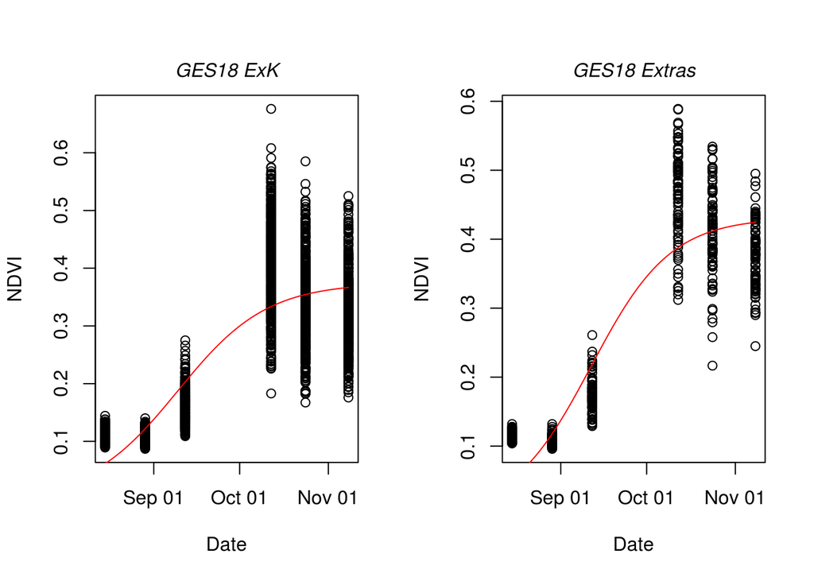

```r
# fit
fit.logis.exk <- gnls(Y ~ SSlogis(X_num, Asym, xmid, scal), data = df_exk)
yfitted.exk <- predict(fit.logis.exk, list(X_num = xNew))

fit.logis.ext <- gnls(Y ~ SSlogis(X_num, Asym, xmid, scal), data = df_ext)
yfitted.ext <- predict(fit.logis.ext, list(X_num = xNew))

par(mfrow = c(1, 2))

# plot
plot(Y ~ X, df_exk, ylab = "NDVI", xlab = "Date")
lines(xNew, yfitted.exk, col = "red")
mtext("GES18 ExK", font = 3, padj = -1)

plot(Y ~ X, df_ext, ylab = "NDVI", xlab = "Date")
lines(xNew, yfitted.ext, col = "red")
mtext("GES18 Extras", font = 3, padj = -1)
```

Visualize scaled residuals and model fits for each model.

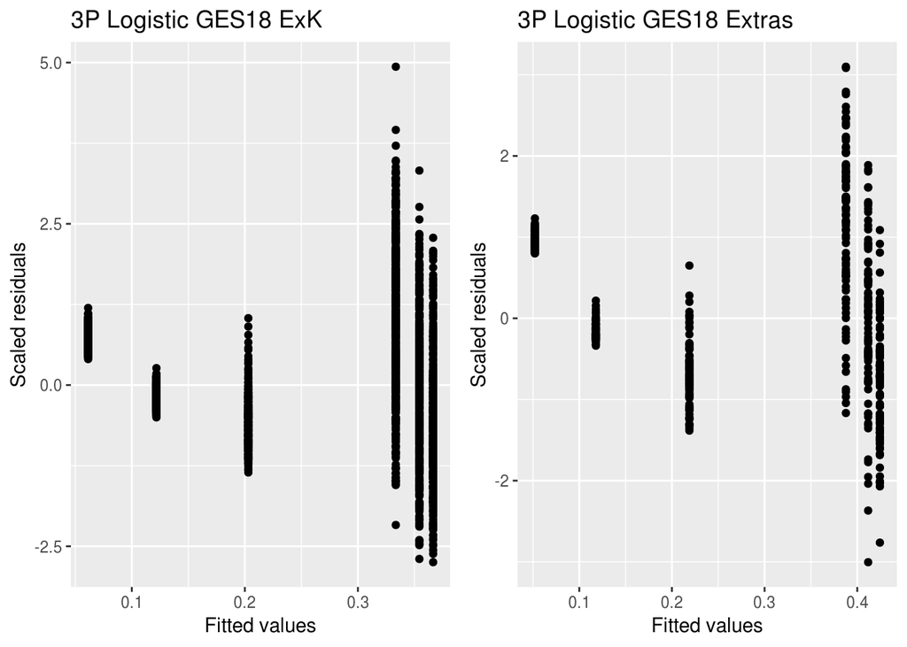

```
##      Model          logLik
## [1,] "Logistic exk" "3145"
## [2,] "Logistic ext" "709"
```

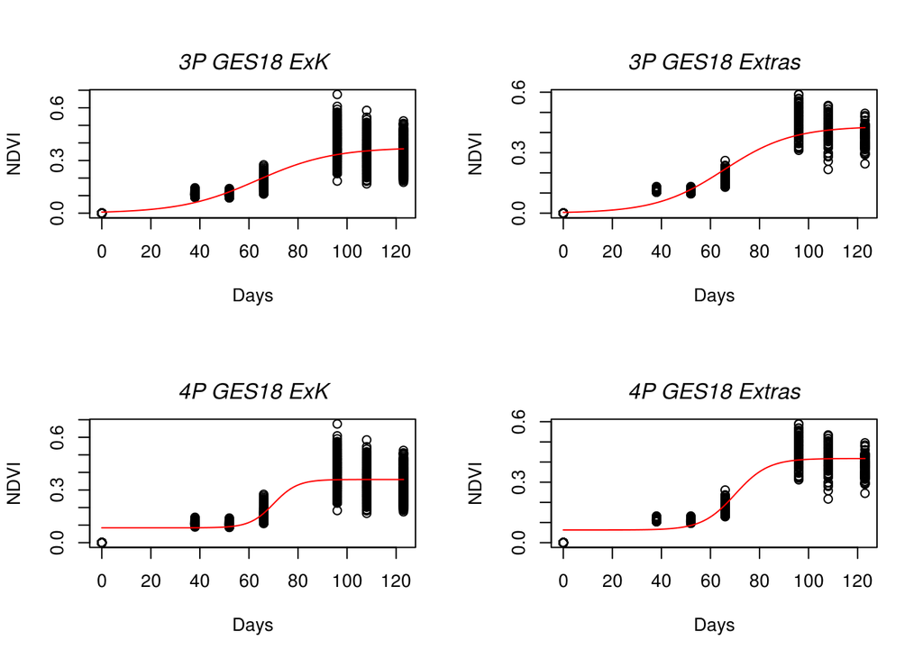

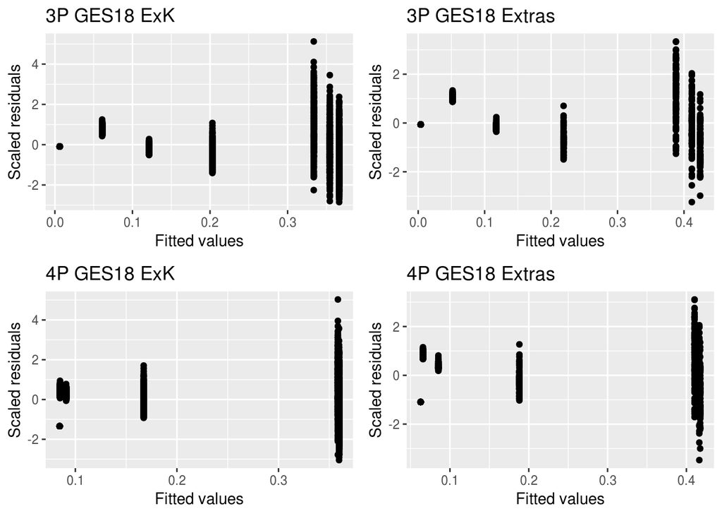

```
##      Model       logLik
## [1,] "3P ExK"    "3502"
## [2,] "3P Extras" "875"
## [3,] "4P ExK"    "3657"
## [4,] "4P Extras" "906"
```

```r
# fit
fit.logis.exk <- gnls(Y ~ SSlogis(X, Asym, xmid, scal), data = df_exk)
yfitted.exk <- predict(fit.logis.exk, list(X = xNew))

fit.logis.ext <- gnls(Y ~ SSlogis(X, Asym, xmid, scal), data = df_ext)
yfitted.ext <- predict(fit.logis.ext, list(X = xNew))

fit.fpl.exk <- gnls(Y ~ SSfpl(X, A, B, xmid, scal), data = df_exk)
yfitted2.exk <- predict(fit.fpl.exk, list(X = xNew))

fit.fpl.ext <- gnls(Y ~ SSfpl(X, A, B, xmid, scal), data = df_ext)
yfitted2.ext <- predict(fit.fpl.ext, list(X = xNew))

par(mfrow = c(2, 2))

# plot
plot(Y ~ X, df_exk, ylab = "NDVI", xlab = "Days")
lines(xNew, yfitted.exk, col = "red")
mtext("3P GES18 ExK", font = 3, padj = -1)

plot(Y ~ X, df_ext, ylab = "NDVI", xlab = "Days")
lines(xNew, yfitted.ext, col = "red")
mtext("3P GES18 Extras", font = 3, padj = -1)

plot(Y ~ X, df_exk, ylab = "NDVI", xlab = "Days")
lines(xNew, yfitted2.exk, col = "red")
mtext("4P GES18 ExK", font = 3, padj = -1)

plot(Y ~ X, df_ext, ylab = "NDVI", xlab = "Days")
lines(xNew, yfitted2.ext, col = "red")
mtext("4P GES18 Extras", font = 3, padj = -1)
```

### Growth rates from 3P logistic regression

Determine AGR, RGRm, and RGRt *per plot* (ie. using plot IDs = “_IW_P_XYZv“) using 3P logistic fit.

```r
par(mfrow = c(3, 3))

# plot and fit to 9 random accessions
for (i in sample(1:length(unique(new_df$group)), size = 9, replace = FALSE)) {
    tryCatch({
        id <- unique(new_df$group)[i]
        a <- subset(new_df, group == id)
        tmp <- getInitial(Y ~ SSlogis(X, Asym, xmid, scal), data = a)
        fit <- gnls(Y ~ SSlogis(X, Asym, xmid, scal), data = a, start = tmp)
        yfitted <- predict(fit, list(X = xNew))

        plot(Y ~ X, a, ylab = "NDVI", xlab = "Days", ylim = c(0, 0.8))
        lines(xNew, yfitted, col = "red")
        mtext(paste(id), font = 3, padj = -1)

    }, error = function(e) {
        cat("ERROR @ #", i, ":", conditionMessage(e), "\n")
    })

}
```

```
## ERROR @ # 46 : number of iterations exceeded maximum of 50
## ERROR @ # 88 : number of iterations exceeded maximum of 50
```

```
## 'log Lik.' 16.49432 (df=4)
```

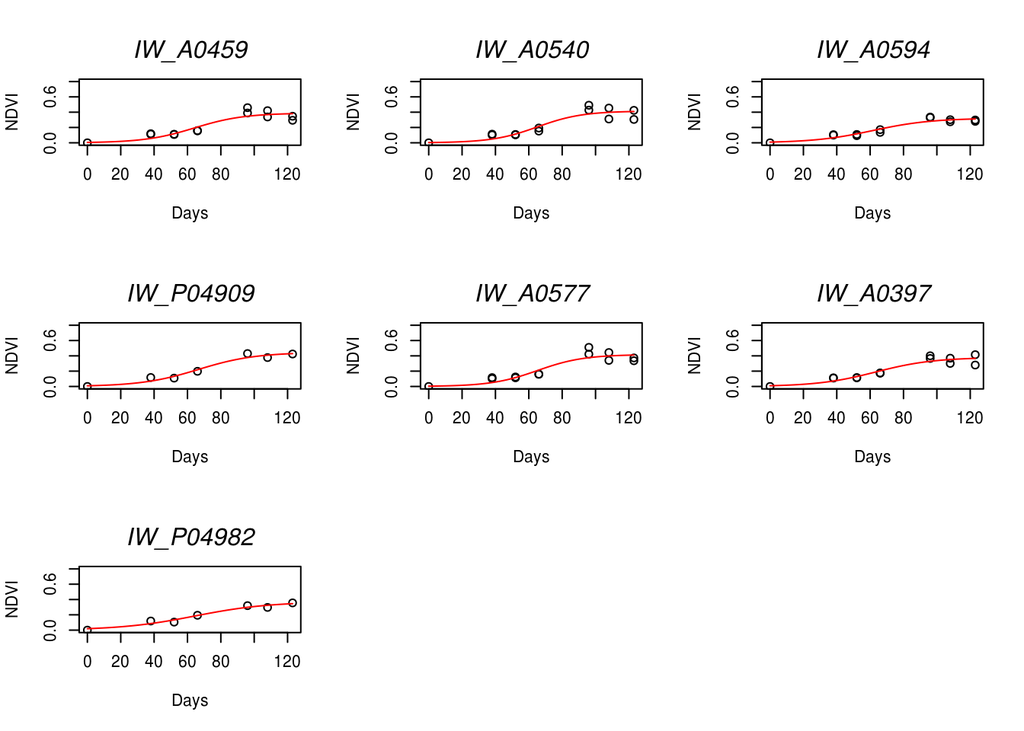

```r
# logLik on last plot
logLik(fit)
```

> 3P logistic seems parsimonious with these datasets. Can use it to assemble coefficients for all plant plot/accessions ideas for the entire GES18 campaign. Any IDs for which the model does not converge are ignored and dropped.

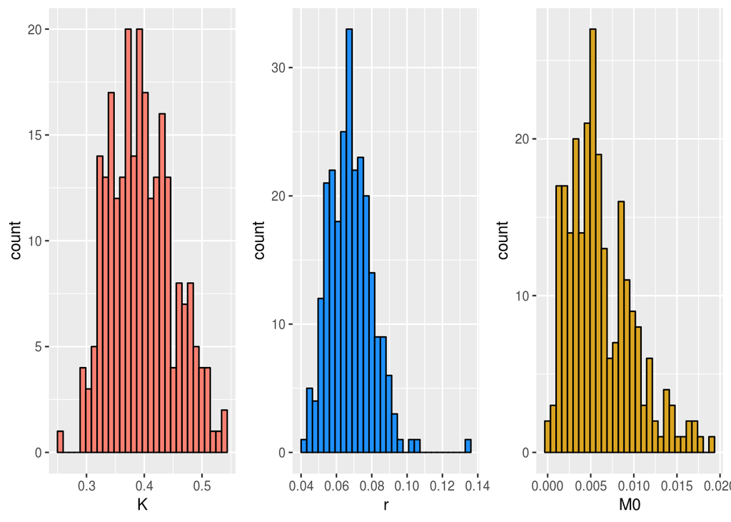

```r
# transform paramters of 3P logistic model
transform_param.logis <- function(coef) {
    K = coef[1]
    r = 1/(coef[3])
    M0 = K/(1 + exp(coef[2]/coef[3]))  #untransform best-fit parameters to K, r and M0
    if (is.data.frame(K)) {
        out <- cbind(K, r, M0)
    } else {
        out <- c(K, r, M0)
    }
    names(out) <- c("K", "r", "M0")
    return(out)
}

cfs_logis <- NULL

for (i in 1:length(unique(new_df$group))) {
    tryCatch({
        id <- unique(new_df$group)[i]
        a <- subset(new_df, group == id)
        tmp <- getInitial(Y ~ SSlogis(X, Asym, xmid, scal), data = a)
        fit <- gnls(Y ~ SSlogis(X, Asym, xmid, scal), data = a, start = tmp)
        x <- transform_param.logis(coef(fit))
        tmp2 <- tibble(id = id, K = x[1], r = x[2], M0 = x[3])
        cfs_logis <- rbind(cfs_logis, tmp2)
    }, error = function(e) {
    })
}

p1 <- ggplot(data = cfs_logis) + geom_histogram(aes(x = K), fill = "salmon",
    colour = "black")
p2 <- ggplot(data = cfs_logis) + geom_histogram(aes(x = r), fill = "dodgerblue",
    colour = "black")
p3 <- ggplot(data = cfs_logis) + geom_histogram(aes(x = M0), fill = "goldenrod",
    colour = "black")

p1 + p2 + p3
```

Check that the parameter profiles are approximately V-shaped (and that the sampling intervals of the parameters are therefore approximately multivariate normal) before proceeding.

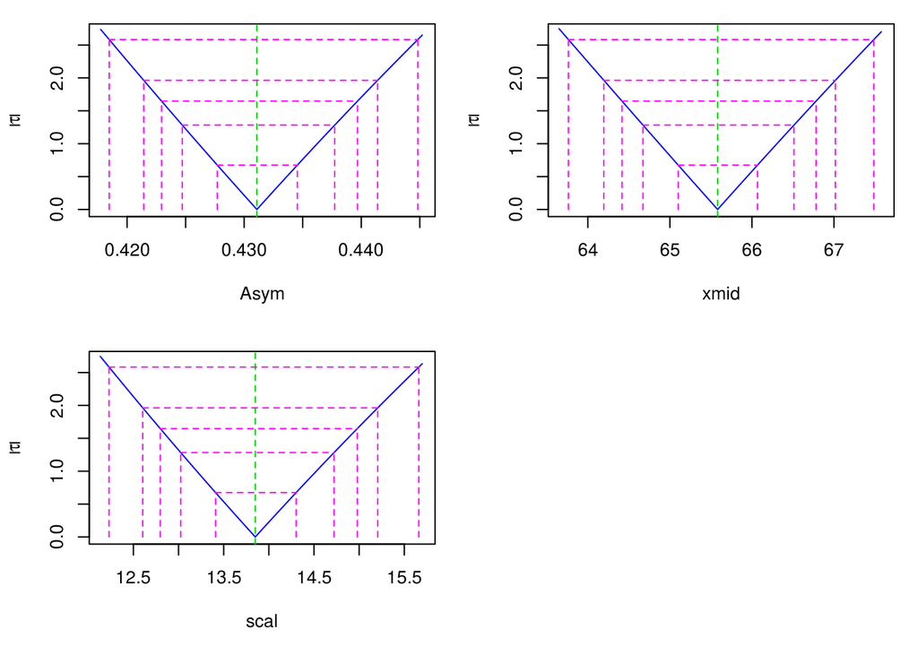

```r
tmp <- getInitial(Y ~ SSlogis(X, Asym, xmid, scal), data = df_ext)
fit <- nls(Y ~ SSlogis(X, Asym, xmid, scal), data = df_ext, start = tmp)

par(mfrow = c(2, 2))

plot(profile(fit))
```

> Profiles are V-shaped

```r
rates <- NULL
cfs <- cfs_logis  # use 3p logistic results

for (i in cfs$id) {
    tmp_rates <- tibble(id = i, K = cfs$K[cfs$id == i], M0 = cfs$M0[cfs$id ==
        i], r = cfs$r[cfs$id == i], times = xNew, M = (M0 * K)/(M0 + (K - M0) *
        exp(-r * times)), AGR = (r * M0 * K * (K - M0) * exp(-r * times))/(M0 +
        (K - M0) * exp(-r * times))^2, RGRt = AGR/M, RGRm = r * (1 - M/K))

    rates <- rbind(rates, tmp_rates)
}

head(rates)
```

```
## # A tibble: 6 x 9
##   id            K      M0      r times       M      AGR   RGRt   RGRm
##   <chr>     <dbl>   <dbl>  <dbl> <dbl>   <dbl>    <dbl>  <dbl>  <dbl>
## 1 IW_P04899 0.430 0.00496 0.0731  0    0.00496 0.000358 0.0723 0.0723
## 2 IW_P04899 0.430 0.00496 0.0731  1.24 0.00542 0.000391 0.0722 0.0722
## 3 IW_P04899 0.430 0.00496 0.0731  2.48 0.00593 0.000428 0.0721 0.0721
## 4 IW_P04899 0.430 0.00496 0.0731  3.73 0.00649 0.000467 0.0720 0.0720
## 5 IW_P04899 0.430 0.00496 0.0731  4.97 0.00709 0.000510 0.0719 0.0719
## 6 IW_P04899 0.430 0.00496 0.0731  6.21 0.00775 0.000557 0.0718 0.0718
```

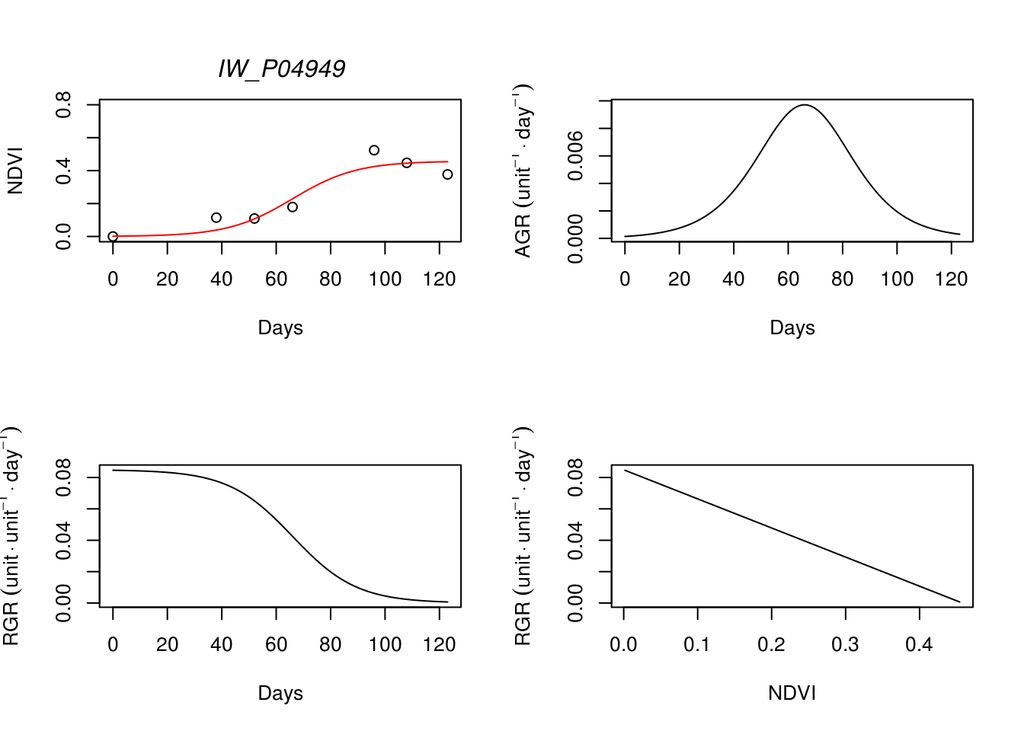

```
## ERROR @ # 120 : number of iterations exceeded maximum of 50
```

```r
par(mfrow = c(2, 2))

for (i in sample(1:length(unique(rates$id)), size = 2, replace = FALSE)) {
    tryCatch({
        Id <- unique(new_df$group)[i]
        a <- subset(new_df, group == Id)

        tmp <- getInitial(Y ~ SSlogis(X, Asym, xmid, scal), data = a)
        fit <- gnls(Y ~ SSlogis(X, Asym, xmid, scal), data = a, start = tmp)
        yfitted <- predict(fit, list(X = xNew))

        # 'biomass'
        plot(Y ~ X, data = a, ylab = "NDVI", xlab = "Days", ylim = c(0, 0.8))
        lines(xNew, yfitted, col = "red")
        mtext(paste(Id), font = 3, padj = -1)

        b <- subset(rates, id == Id)

        # AGR
        plot(AGR ~ times, data = b, type = "n", xlab = "Days", ylab = expression(paste("AGR ",
            (unit^-1 %.% day^-1))))
        lines(AGR ~ times, data = b)

        # RGRt
        plot(RGRt ~ times, data = b, type = "n", xlab = "Days", ylab = expression(paste("RGR ",
            (unit %.% unit^-1 %.% day^-1))))
        lines(RGRt ~ times, data = b)

        # RGRm
        plot(RGRm ~ M, data = b, type = "n", xlab = "NDVI", ylab = expression(paste("RGR ",
            (unit %.% unit^-1 %.% day^-1))))
        lines(RGRm ~ M, data = b)
    }, error = function(e) {
        cat("ERROR @ #", i, ":", conditionMessage(e), "\n")
    })

}
```

### Growth rates from 4P logistic regression

Determine AGR, RGRm, and RGRt *per plot* (ie. using plot IDs = “_IW_P_XYZv“) using 4P logistic fit.

```r
par(mfrow = c(3, 3))

# plot and fit to 9 random accessions
for (i in sample(1:length(unique(df_ext$group)), size = 9, replace = FALSE)) {
    tryCatch({
        id <- unique(df_ext$group)[i]
        a <- subset(df_ext, group == id)
        tmp <- getInitial(Y ~ SSfpl(X, A, B, xmid, scal), data = a)  #4p logistic
        fit <- gnls(Y ~ SSfpl(X, A, B, xmid, scal), data = a, start = tmp)  #4p logistic
        yfitted <- predict(fit, list(X = xNew))

        plot(Y ~ X, a, ylab = "NDVI", xlab = "Days", ylim = c(0, 0.8))
        lines(xNew, yfitted, col = "red")
        mtext(paste(id), font = 3, padj = -1)

    }, error = function(e) {
        cat("ERROR @ #", i, ":", conditionMessage(e), "\n")
    })

}
```

```
## ERROR @ # 54 : number of iterations exceeded maximum of 50
```

```
## 'log Lik.' 10.87304 (df=5)
```

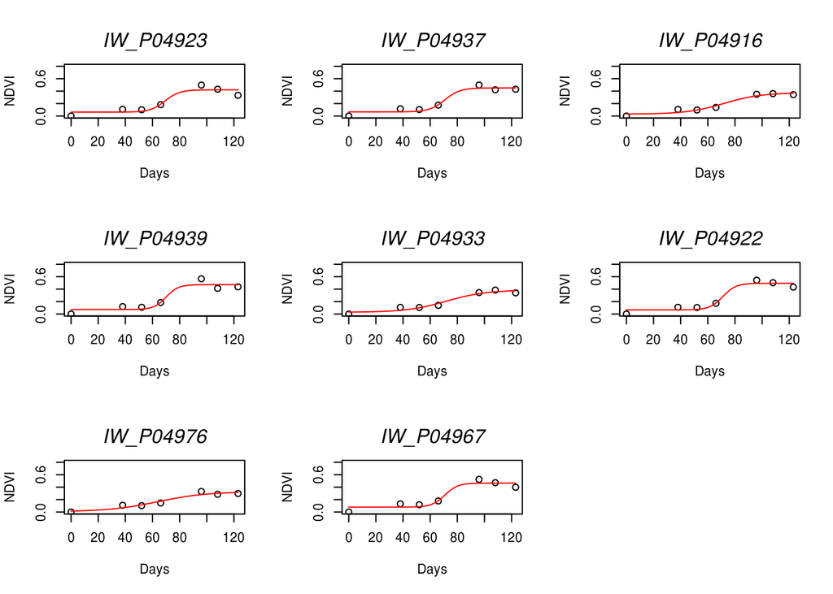

```r
# logLik on last plot
logLik(fit)
```

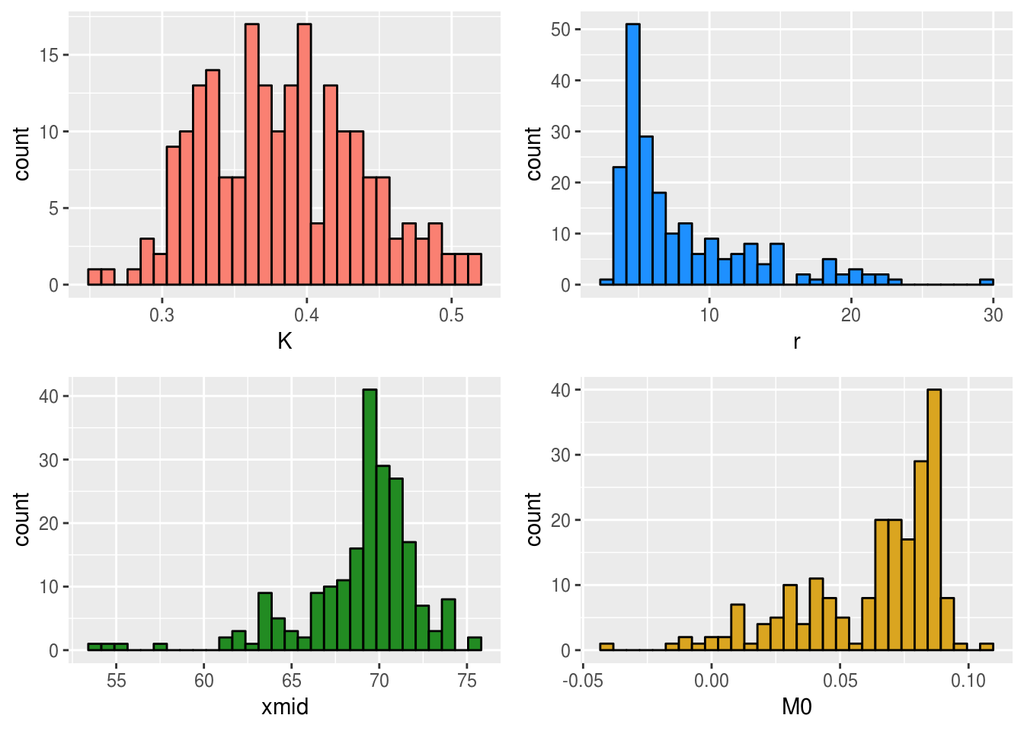

```r
## fit fpl on all accessions and extract coefficients based on Paine et al
## 2012.
cfs_fpl <- NULL

for (i in 1:length(unique(new_df$group))) {
    tryCatch({
        id <- unique(new_df$group)[i]
        a <- subset(new_df, group == id)
        tmp <- getInitial(Y ~ SSfpl(X, A, B, xmid, scal), data = a)  #4p logistic
        fit <- gnls(Y ~ SSfpl(X, A, B, xmid, scal), data = a, start = tmp)  #4p logistic
        x <- coef(fit)
        tmp2 <- tibble(id = id, M0 = x[1], K = x[2], xmid = x[3], r = x[4])
        cfs_fpl <- rbind(cfs_fpl, tmp2)
    }, error = function(e) {
    })
}

p1 <- ggplot(data = cfs_fpl) + geom_histogram(aes(x = K), fill = "salmon", colour = "black")
p2 <- ggplot(data = cfs_fpl) + geom_histogram(aes(x = r), fill = "dodgerblue",
    colour = "black")
p4 <- ggplot(data = cfs_fpl) + geom_histogram(aes(x = xmid), fill = "forestgreen",
    colour = "black")
p3 <- ggplot(data = cfs_fpl) + geom_histogram(aes(x = M0), fill = "goldenrod",
    colour = "black")

p1 + p2 + p4 + p3
```

Before trying to make predictions, we also want to make sure we can propagate error in parameter estimates into growth rate estimates. Before propagating error, we need to check that the parameter profiles are approximately V-shaped (and that the sampling intervals of the parameters are therefore approximately multivariate normal) before proceeding.

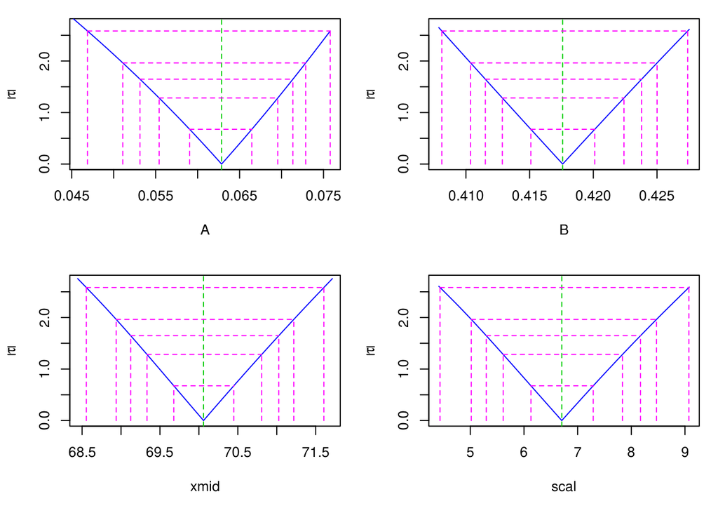

```r
tmp <- getInitial(Y ~ SSfpl(X, A, B, xmid, scal), data = df_ext)
fit <- nls(Y ~ SSfpl(X, A, B, xmid, scal), data = df_ext, start = tmp)

par(mfrow = c(2, 2))

plot(profile(fit))
```

> Profiles are v-shaped

```r
rates <- NULL
cfs <- cfs_fpl  # use 4p logistic results

for (i in cfs$id) {
    tmp_rates <- tibble(id = i, K = cfs$K[cfs$id == i], M0 = cfs$M0[cfs$id ==
        i], xmid = cfs$xmid[cfs$id == i], r = cfs$r[cfs$id == i], times = xNew,
        ex = exp((xmid - times)/r), M = M0 + (K - M0)/(1 + ex), AGR = ((K -
            M0) * ex)/(r * (1 + ex)^2), RGRt = AGR/M, RGRm = ((M0 - M) * (K -
            M))/(r * M * (M0 - K)))

    rates <- rbind(rates, tmp_rates)
}

head(rates, n = 3)
```

```
## # A tibble: 3 x 11
##   id            K     M0  xmid     r times    ex      M       AGR    RGRt
##   <chr>     <dbl>  <dbl> <dbl> <dbl> <dbl> <dbl>  <dbl>     <dbl>   <dbl>
## 1 IW_P04899 0.425 0.0383  64.2  10.6  0     434. 0.0392 0.0000839 0.00214
## 2 IW_P04899 0.425 0.0383  64.2  10.6  1.24  386. 0.0393 0.0000943 0.00240
## 3 IW_P04899 0.425 0.0383  64.2  10.6  2.48  343. 0.0394 0.000106  0.00269
## # ... with 1 more variable: RGRm <dbl>
```

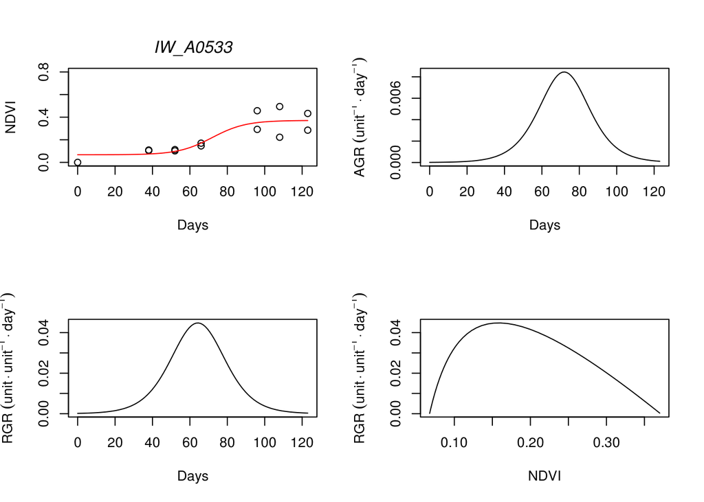

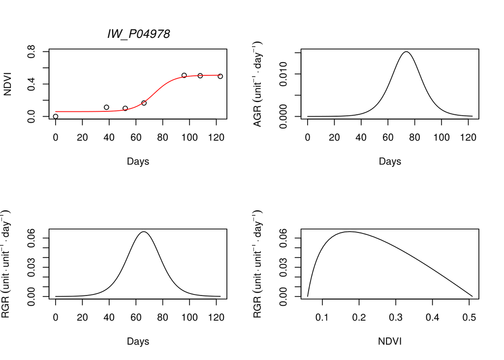

```r
par(mfrow = c(2, 2))

# plot and fit to 9 random accessions
for (i in sample(1:length(unique(rates$id)), size = 2, replace = FALSE)) {
    tryCatch({
        Id <- unique(new_df$group)[i]
        a <- subset(new_df, group == Id)

        tmp <- getInitial(Y ~ SSfpl(X, A, B, xmid, scal), data = a)  #4p logistic
        fit <- gnls(Y ~ SSfpl(X, A, B, xmid, scal), data = a, start = tmp)  #4p logistic
        yfitted <- predict(fit, list(X = xNew))

        # 'biomass'
        plot(Y ~ X, data = a, ylab = "NDVI", xlab = "Days", ylim = c(0, 0.8))
        lines(xNew, yfitted, col = "red")
        mtext(paste(Id), font = 3, padj = -1)

        b <- subset(rates, id == Id)

        # AGR
        plot(AGR ~ times, data = b, type = "n", xlab = "Days", ylab = expression(paste("AGR ",
            (unit^-1 %.% day^-1))))
        lines(AGR ~ times, data = b)

        # RGRt
        plot(RGRt ~ times, data = b, type = "n", xlab = "Days", ylab = expression(paste("RGR ",
            (unit %.% unit^-1 %.% day^-1))))
        lines(RGRt ~ times, data = b)

        # RGRm
        plot(RGRm ~ M, data = b, type = "n", xlab = "NDVI", ylab = expression(paste("RGR ",
            (unit %.% unit^-1 %.% day^-1))))
        lines(RGRm ~ M, data = b)
    }, error = function(e) {
        cat("ERROR @ #", i, ":", conditionMessage(e), "\n")
    })

}
```